# Personal Activity

Mao Soldevilla

7/10/2020

## Overview

In this project, I will be to use data from accelerometers on the belt, forearm, arm, and dumbell of 6 participants. They were asked to perform barbell lifts correctly and incorrectly in 5 different ways. More information is available from the website here: http://groupware.les.inf.puc-rio.br/har (see the section on the Weight Lifting Exercise Dataset).

### Data

The training data for this project are available here: https://d396qusza40orc.cloudfront.net/predmachlearn/pml-training.csv

The test data are available here:

https://d396qusza40orc.cloudfront.net/predmachlearn/pml-testing.csv

The data for this project come from this source: http://groupware.les.inf.puc-rio.br/har.

## 1. Data Exploratory

### Loading Lybraries

```r
library(lattice)
library(ggplot2)
library(caret)
library(AppliedPredictiveModeling)
library(dplyr)
```

### Loading data

```r
# Training
url1 <- "https://d396qusza40orc.cloudfront.net/predmachlearn/pml-training.csv"
training <- read.csv(url1)
# Testing
url2 <- "https://d396qusza40orc.cloudfront.net/predmachlearn/pml-testing.csv"
testing <- read.csv(url2)
dim(training); dim(testing)
```

```
## [1] 19622   160
```

```
## [1]  20 160
```

Both are the same size of variables

### Cleaning vars with NAs.

In order to avoid bias, is better to delete vars with a high rate of **NA** values.

```r
delvarNA <- which(colMeans(is.na(training)) > 0)
training <- training[ , -delvarNA]
testing <- testing[ , -delvarNA]
```

### Cleaning vars with voids data

In order to avoid bias, is better to delete vars with a high rate of **void** values.

```r
delvoid <- which(colMeans(training == "") > 0)
training <- training[ , -delvoid]
testing <- testing[ , -delvoid]
```

### Cleaning non important vars.

It does not give important information the dates, delete dates vars

```r
# Deleting times
training <- training[, -c(1:7)]
testing <- testing[, -c(1:7)]
```

### Cleaning total vars.

In order to avoid bias, is better to delete vars with a high rate of **total** values.

```r
# Deleting totals
training <- select(training, -c(grep("^total", names(training))))
testing <- select(testing, -c(grep("^total", names(testing))))
dim(training)
```

```
## [1] 19622    49
```

### Training ad fitting

Now with a clean data is possible to train, for then we split the data into train for training the model and valid for use in the validation of the model

```r
inTrain = createDataPartition(y = training$classe, p = 0.7, list = FALSE)
train <- training[inTrain, ]
valid <- training[-inTrain, ]
```

We will try to find the best model testing some methods saw in the course that are **Random Forest**, **Gradient Boosted Trees** and **Linear Discriminant Analyses**

#### Setting up control for training to use 3-fold cross validation.

```r
control <- trainControl(method = "cv", number = 3, verboseIter = FALSE)
```

#### Random Forest

```r
fitModrf <- train(classe ~ ., data = train, method = "rf", trControl = control)
predrf <- predict(fitModrf, valid)
cmrf <- confusionMatrix(predrf, factor(valid$classe))
cmrf
```

```
## Confusion Matrix and Statistics
##
##           Reference
## Prediction    A    B    C    D    E
##          A 1673    8    0    0    1
##          B    1 1130    4    1    1
##          C    0    1 1020    6    1
##          D    0    0    2  956    4
##          E    0    0    0    1 1075
##
## Overall Statistics
##
##                Accuracy : 0.9947
##                  95% CI : (0.9925, 0.9964)
##     No Information Rate : 0.2845
##     P-Value [Acc > NIR] : < 2.2e-16
##
##                   Kappa : 0.9933
##
##  Mcnemar's Test P-Value : NA
##
## Statistics by Class:
##
##                      Class: A Class: B Class: C Class: D Class: E
## Sensitivity            0.9994   0.9921   0.9942   0.9917   0.9935
## Specificity            0.9979   0.9985   0.9984   0.9988   0.9998
## Pos Pred Value         0.9946   0.9938   0.9922   0.9938   0.9991
## Neg Pred Value         0.9998   0.9981   0.9988   0.9984   0.9985
## Prevalence             0.2845   0.1935   0.1743   0.1638   0.1839
## Detection Rate         0.2843   0.1920   0.1733   0.1624   0.1827
## Detection Prevalence   0.2858   0.1932   0.1747   0.1635   0.1828
## Balanced Accuracy      0.9986   0.9953   0.9963   0.9952   0.9967
```

#### Gradient Boosted Trees.

```r
fitModgbm <- train(classe ~ ., data = train, method = "gbm", trControl = control, verbose = FALSE)
predgbm <- predict(fitModgbm, valid)
cmgbm <- confusionMatrix(predgbm, factor(valid$classe))
cmgbm
```

```
## Confusion Matrix and Statistics
##
##           Reference
## Prediction    A    B    C    D    E
##          A 1649   33    0    0    3
##          B   20 1066   36    2   13
##          C    3   34  978   26    7
##          D    1    1   12  931   14
##          E    1    5    0    5 1045
##
## Overall Statistics
##
##                Accuracy : 0.9633
##                  95% CI : (0.9582, 0.968)
##     No Information Rate : 0.2845
##     P-Value [Acc > NIR] : < 2e-16
##
##                   Kappa : 0.9536
##
##  Mcnemar's Test P-Value : 0.00147
##
## Statistics by Class:
##
##                      Class: A Class: B Class: C Class: D Class: E
## Sensitivity            0.9851   0.9359   0.9532   0.9658   0.9658
## Specificity            0.9915   0.9850   0.9856   0.9943   0.9977
## Pos Pred Value         0.9786   0.9376   0.9332   0.9708   0.9896
## Neg Pred Value         0.9940   0.9846   0.9901   0.9933   0.9923
## Prevalence             0.2845   0.1935   0.1743   0.1638   0.1839
## Detection Rate         0.2802   0.1811   0.1662   0.1582   0.1776
## Detection Prevalence   0.2863   0.1932   0.1781   0.1630   0.1794
## Balanced Accuracy      0.9883   0.9605   0.9694   0.9800   0.9818
```

#### Linear Discriminant Analisys

```r
fitModlda <- train(classe ~ ., data = train, method = "lda", trControl = control)
predlda <- predict(fitModlda, valid)
cmlda <- confusionMatrix(predlda, factor(valid$classe))
cmlda
```

```
## Confusion Matrix and Statistics
##
##           Reference
## Prediction    A    B    C    D    E
##          A 1370  176  120   64   49
##          B   58  693   84   72  177
##          C  125  138  689  115   86
##          D  106   56  111  670  132
##          E   15   76   22   43  638
##
## Overall Statistics
##
##                Accuracy : 0.6899
##                  95% CI : (0.6779, 0.7017)
##     No Information Rate : 0.2845
##     P-Value [Acc > NIR] : < 2.2e-16
##
##                   Kappa : 0.6072
##
##  Mcnemar's Test P-Value : < 2.2e-16
##
## Statistics by Class:
##
##                      Class: A Class: B Class: C Class: D Class: E
## Sensitivity            0.8184   0.6084   0.6715   0.6950   0.5896
## Specificity            0.9029   0.9176   0.9045   0.9177   0.9675
## Pos Pred Value         0.7701   0.6393   0.5976   0.6233   0.8035
## Neg Pred Value         0.9260   0.9071   0.9288   0.9389   0.9128
## Prevalence             0.2845   0.1935   0.1743   0.1638   0.1839
## Detection Rate         0.2328   0.1178   0.1171   0.1138   0.1084
## Detection Prevalence   0.3023   0.1842   0.1959   0.1827   0.1349
## Balanced Accuracy      0.8606   0.7630   0.7880   0.8064   0.7786
```

### Summary

```r
data.frame(accuracy = c(cmrf$overall[[1]], cmgbm$overall[[1]], cmlda$overall[[1]]),
           oos = c(1 - cmrf$overall[[1]], 1 - cmgbm$overall[[1]], 1 - cmlda$overall[[1]]))
```

```
##    accuracy        oos
## 1 0.9947324 0.00526763
## 2 0.9632965 0.03670348
## 3 0.6898895 0.31011045
```

According the result, the best model is **Random Forest** with an accuracy of 0.9947324

### Predicting the test set.

```r
predtest <- predict(fitModrf, testing)
print(predtest)
```

```
##  [1] B A B A A E D B A A B C B A E E A B B B
## Levels: A B C D E
```

### Appendix

Plotting the models with best rates.

#### Random Forest

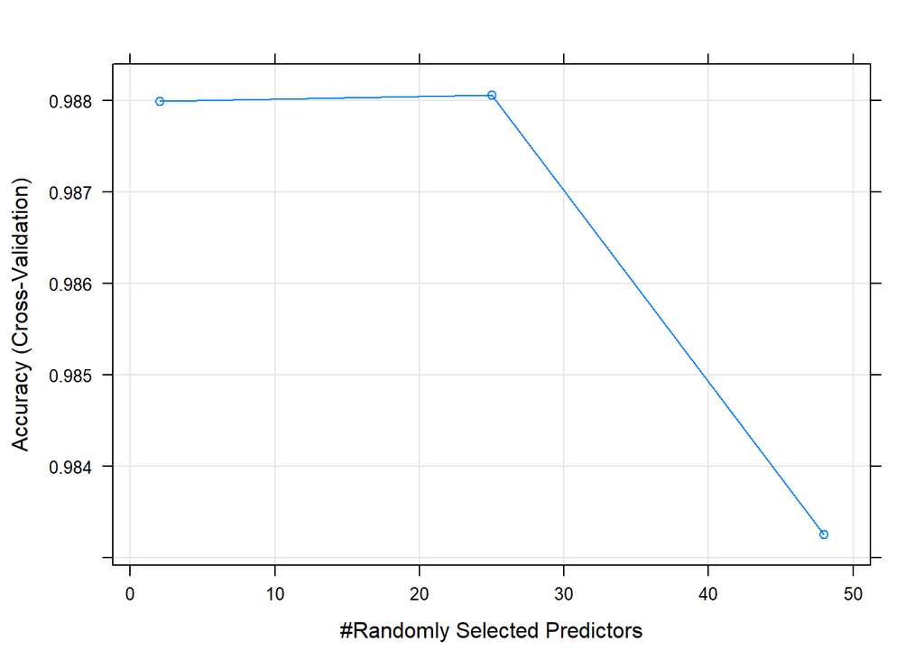

```r
plot(fitModrf)
```

#### Gradient Boosted Trees

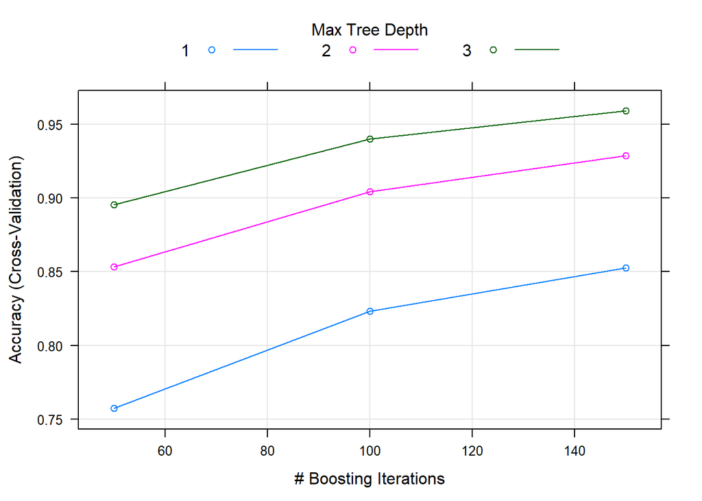

```r
plot(fitModgbm)
```